# ChIPseq analysis

Jenny Jakobsson

11/11/2020

# ChIPseq CBP data analysis

## Loading data

```r
#Load in the path to the CBP featureCount file
featureCountFile = paste(params$workingDir, params$dataDir, params$chipSeqData, sep = "/")

#Load the featurecount file into a table
FCdata = read.table(file = featureCountFile, header = TRUE, sep = "\t", quote = "", stringsAsFactors = FALSE)

#Select the geneID, chromosome, start, end, strand and length.
peakInfo  = FCdata [,1:6]
peakInfo = peakInfo %>% dplyr::rename(geneID = Geneid)


#Select the rest of the columns from the featureCount file, the counts.
countData = FCdata[,-1:-6]
rownames(countData) = peakInfo$geneID
```

## Create sample information

Extracting the information from the sample name so it is more easily accessible in a data frame. The sample information is sample name, mutant, time, replicate and bam file name.

```r
#Rename the labels for the labels in countData so that they just have the mutant name and replicate and input/CBP
samples = colnames(countData)
samples = gsub(pattern = "..CBP_ChIP_seq_mapped.CBP_toll_dm6only.bam_dm6.", replacement = "", x = samples)
samples = gsub(pattern = ".dm6.bowtie2.sorted.bam", replacement = "", x = samples)
colnames(countData) = samples

#Create a table with more information about the samples and create good names
sampleInfo = data.frame(sampleName = colnames(countData), sampleInfo = samples, stringsAsFactors = F)
sampleInfo= sampleInfo %>% separate(sampleInfo, c("Genotype", "Replicate", "Input", "sample"), sep = "_", remove = F)
sampleInfo$Genotype = recode(sampleInfo$Genotype, toll910 = "Toll9")
sampleInfo$Genotype = recode(sampleInfo$Genotype, gd7 = "Gd7")
sampleInfo$Genotype = recode(sampleInfo$Genotype, toll10B = "Toll10b")
sampleInfo$sampleID = paste(sampleInfo$Genotype, sampleInfo$Replicate, sampleInfo$Input , sep = "_")

#Make sure that CountData only contains the samples that has names in sampleName and change the name in countData
countData = countData[,sampleInfo$sampleName]
colnames(countData) = sampleInfo$sampleID
```

## Differential expression analysis and filtering

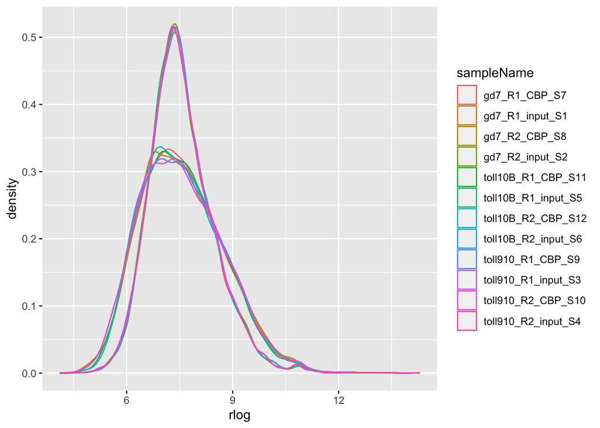

```r
#Expression data is now the count data and meta info is the info about the samples.
exp.data = countData
metaInfo = sampleInfo

#Change the rownames to the names that inform on the mutant, replicate and CPB/input
rownames(metaInfo) = sampleInfo$sampleID

#Convert some of the columns to factors
metaInfo$Genotype = as.factor(metaInfo$Genotype)
metaInfo$sampleID = as.factor(metaInfo$sampleID)
metaInfo$Input = as.factor(metaInfo$Input)

#Create a DESeq dataset
dds <- DESeqDataSetFromMatrix(countData = exp.data,
                               colData = metaInfo, ~1)

#Remove rows with low counts and normalize samples for visualization
dds <- dds[ rowSums(counts(dds)) > 100, ]


#Transform the count data in the DESeq data frame to the log2 scale which minimizes differences between samples for rows with small counts, and which normalizes with respect to library size
rld <- rlog(dds)

#Put this normalized data into a data frame
normExpression = as.data.frame(assay(rld))

#Create a normalized expression data frame
normExpression$geneID = rownames(normExpression)
normExpressionDF  = normExpression %>% gather( key = sampleID, value = rlog, -geneID)
normExpressionDF = inner_join(normExpressionDF, metaInfo)

#Plot the CBP and input samples as one line each
ggplot(normExpressionDF, aes(x = rlog, color = sampleName)) + geom_density()
```

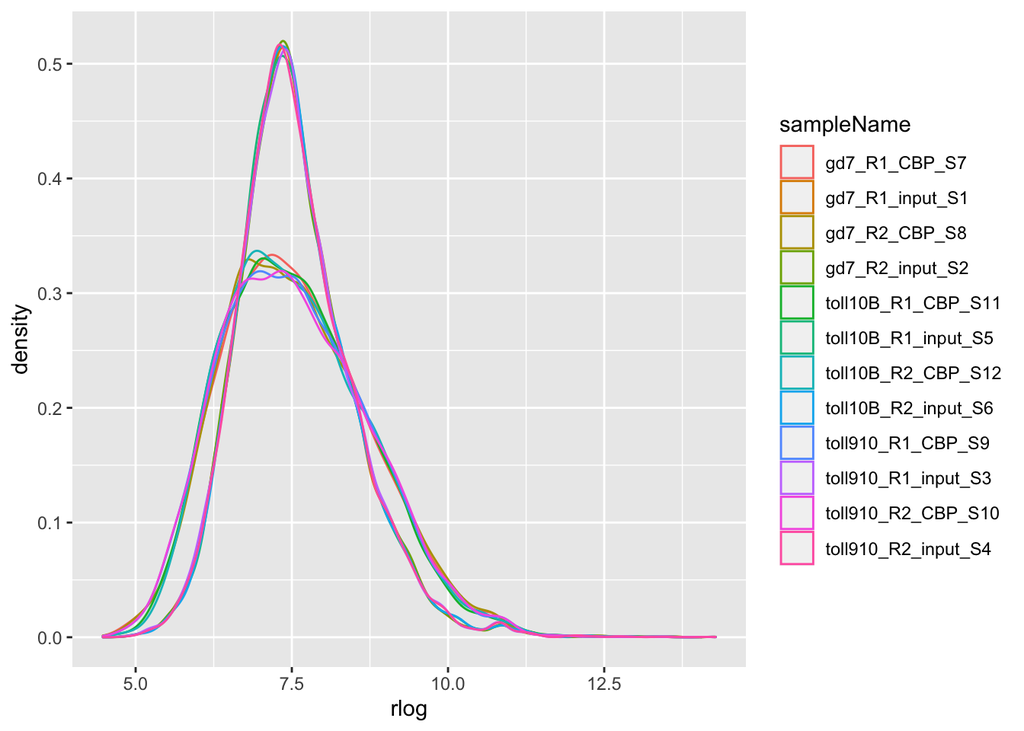

```r
peakInfo1 = normExpressionDF %>% dplyr::select(geneID, rlog, sampleName) %>%
  dplyr::group_by (geneID) %>%
  dplyr::summarize ( min = min(rlog), max = max(rlog), mean = mean(rlog), sd = sd(rlog), overQC = length(which(rlog > 5)) )

#Filter out so that peakInfo.QC only has overQC values above 2.
peakInfo.QC = peakInfo1 %>% filter(overQC > 2)
#Filter so that normExpressionDF.QC only contains elements with a geneID that also is in peakInfo.QC
normExpressionDF.QC = normExpressionDF %>% filter(geneID %in% peakInfo.QC$geneID)

#Plot the filtered normExpressionDF, but coloring sampleName now
ggplot(normExpressionDF.QC, aes(x = rlog, color = sampleName)) + geom_density()
```

```r
#Filter to only contain CBP and not Input.
normExpressionDF.QC.CBP = normExpressionDF.QC %>% filter(Input == params$Antibody)
normExpression.QC = normExpressionDF.QC.CBP %>%
  dplyr::select(geneID, sampleName, rlog) %>%
  spread(key = sampleName, value = rlog)

rownames(normExpression.QC) = normExpression.QC$geneID
normExpression.QC = normExpression.QC[, -1]
```

### Visualizing the data

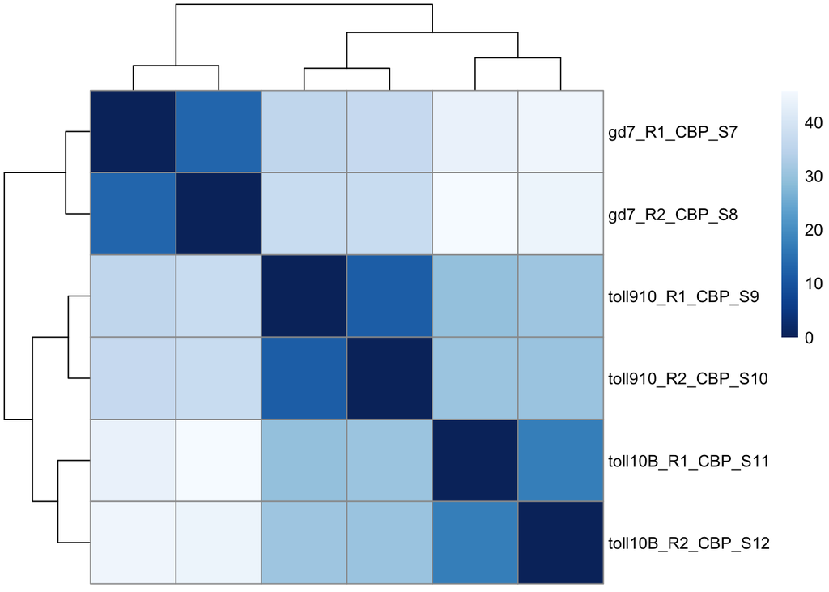

```r
#Plot a new heat map with only CBP
plotSample2SampleDistance(normExpression.QC)
```

### Principal components analysis with normalised counts

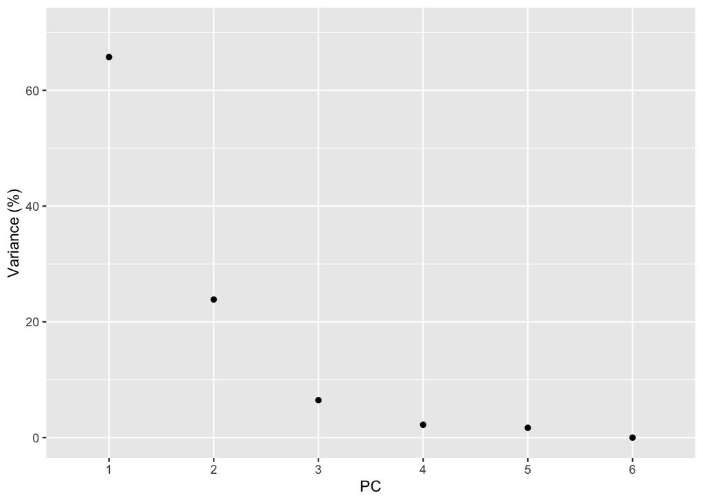

```r
#Do a PCA analysis
mir.pca <-
  prcomp(t(normExpression.QC), center = TRUE, scale = FALSE)
#Calculate evar from the PCA output
e.var = (mir.pca[['sdev']] ^ 2 / sum(mir.pca[['sdev']] ^ 2))
#Make e.var to a data frame
e.var = as.data.frame(e.var)
#Add column named PC
e.var$PC = as.factor(1:nrow(e.var))
#Add column with the varience
e.var$Variance = e.var$e.var * 100
#Add column with CumulativeVariance
e.var$CumulativeVariance = cumsum(e.var$Variance)
#Plot each PC component and its variance.
qplot(
  PC,
  Variance,
  data = e.var,
  geom = c("point")
  ,
  ylim = c(0, max(e.var$Variance) + 5)
  ,
  ylab = "Variance (%)"
)
```

```r
#Make the first 5 PCA output to a data frame.
pctable = as.data.frame(mir.pca$x)[, 1:5]
#Add column with sample name
pctable$sampleName = rownames(pctable)
#Add the metainfo
pctable = inner_join(pctable, metaInfo)
```

```r
#Plot using a function in ExpressionAnalysisFucntions
pca  = plotPCAplot(
  PCAinfo = pctable,
  n.comp = 4,
  varianceInfo = e.var,
  colorComponent = "Genotype"
)
```

```
##          PC1        PC2       PC3       PC4 Genotype colorComponent
## 1 -23.756090   4.269306  5.082509 -1.270749      Gd7            Gd7
## 2 -24.780499   4.750149 -4.764066  1.357778      Gd7            Gd7
## 3  18.824146   9.855031  8.216145  2.210497  Toll10b        Toll10b
## 4  18.434520  10.951735 -8.050632 -2.123528  Toll10b        Toll10b
## 5   5.446551 -14.703902  1.937560 -5.219385    Toll9          Toll9
## 6   5.831373 -15.122320 -2.421517  5.045387    Toll9          Toll9
```

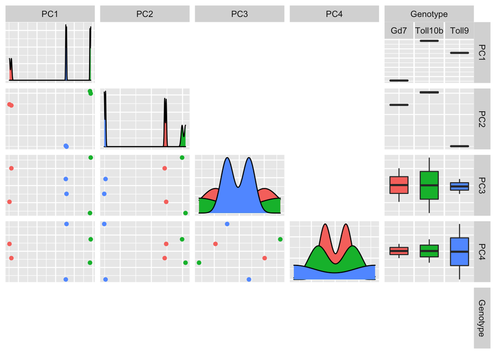

```r
# Need to actually run the command to output plot
pca
```

```r
# Calculate the mean of the PC to plot lines with respect to mutants
mean = pctable %>% dplyr::select(PC1, PC2, PC3, Genotype) %>%
  dplyr::group_by(Genotype) %>%
  dplyr::summarise(PC1 = mean(PC1) ,
                   PC2 = mean(PC2),
                   PC3 = mean(PC3))
origo = data.frame(PC1 = 0, PC2 = 0, PC3 = 0)

# Create a vector plot with the values (-mean, origo, mean) for each mutant
line.gd7 = rbind(mean[1, 2:4], origo, -mean[1, 2:4])
line.gd7$factor = "Gd7"
line.toll10b = rbind(mean[2, 2:4], origo, -mean[2, 2:4])
line.toll10b$factor = "Toll10b"
line.toll9 = rbind(mean[3, 2:4], origo, -mean[3, 2:4])
line.toll9$factor = "Toll9"
line = rbind(line.gd7, line.toll10b, line.toll9)
```

### Plotting

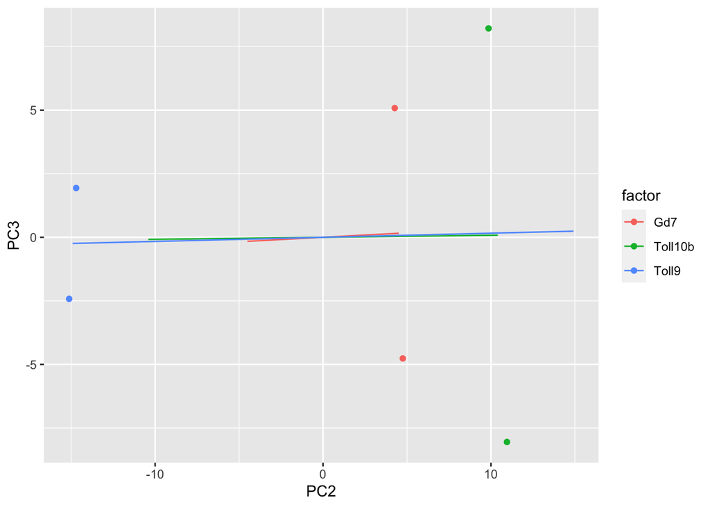

```r
ggplot(line, mapping = aes(x = PC2, y = PC3, color = factor)) + geom_line() + geom_point(data = pctable,
                                                                                         mapping = aes(x = PC2, y = PC3, color = Genotype))
```

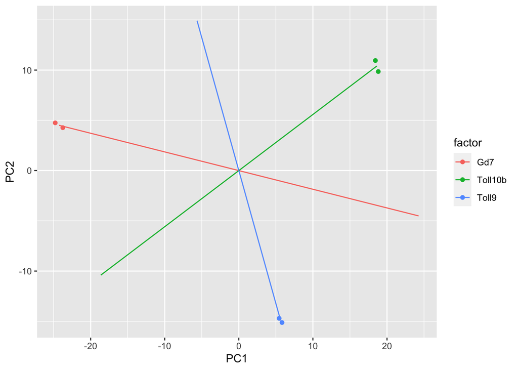

```r
ggplot(line, mapping = aes(x = PC1, y = PC2, color = factor)) + geom_line() + geom_point(data = pctable,
                                                                                         mapping = aes(x = PC1, y = PC2, color = Genotype))
```

## Gene scores

The sequencing data has a lot of dimension, time and the different mutants. We want to reduce the number of dimensions to a single score. This is done by the loading scores found by PCA. The loading scores are used as a distance. The distance will then tell us how much variance is found, i.e. the bigger the distance the more it is different. We can e.g. from the scores say if a sample is up-regulated with respect to gd7

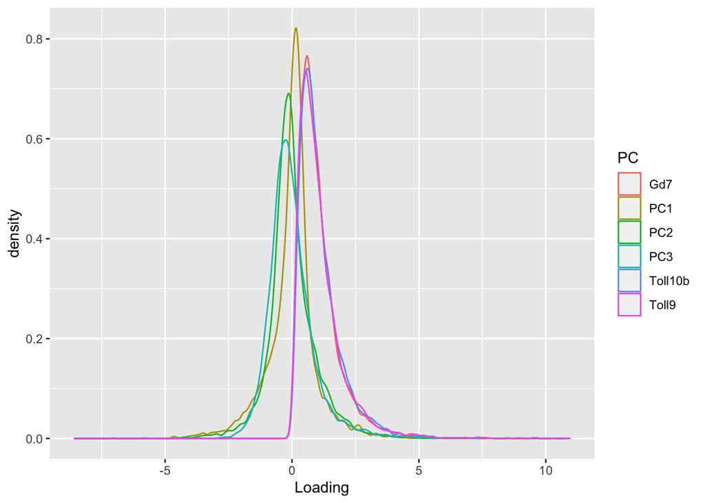

```r
# Saves the loading scores for PC1-PC3
line = rbind(line.gd7, line.toll10b, line.toll9)
loadings = mir.pca$rotation[, 1:3]

# Converts the loading values into z-values. A positive z-value ==> above average, negative ==> below average, 0 ==> average.
loadings_norm = as.data.frame(t((t(loadings) - colMeans(loadings)) / colSds(loadings)))
loadings_norm$geneID = rownames(loadings)

# We calculate the distance of each sample and mutant in the 3D space of PC1-3. The mean is seen as the "normal" regulation and the distance is a measure of how large of a variance.
loadings_new = loadings_norm
for (j in unique(line$factor)) {
  loadings_new[[j]] = 0
  for (i in 1:nrow(loadings_norm)) {
    line1 = line %>% dplyr::filter(factor == j) %>% dplyr::select(PC1, PC2, PC3)
    loadings_new[i, j] = dist3d(
      b = as.numeric(line1[1, ]),
      c = as.numeric(line1[3, ]),
      point = as.numeric(loadings_new[i, 1:3])
    )

  }

}
# Gather all of the new distances in a data frame for plotting
loadingsDF = gather(loadings_new, key = PC, value = Loading,-geneID)
ggplot(loadingsDF, mapping = aes(x = Loading, color = PC)) + geom_density()
```

```r
# Recreates the same data fram as loadings_new but in another column order
loadingsDF.all = loadingsDF %>%  spread(key = PC, value = Loading)

# Take the absolute value of the distance of the PC, to be able to compare them to each other and add it as a column to a new data frame
tmp = loadingsDF.all
tmp$distance =  ((tmp$PC1 ^ 2 + tmp$PC2 ^ 2 + tmp$PC3 ^ 2) ^ 0.5)
loadingsDF.all = tmp
loadingsDF.all.factorDistance = loadingsDF.all %>% gather(key = factor, value = distance2Factor, Gd7, Toll10b, Toll9)

# Calculates the distance by taking the distance for the loading scores to the distance to the factor(mutants or time). The bigger difference the more it is deviating form the norm. This means there will be one distance for each CBP Peak. (e.g. region 100 will have 4 column (time and mutants))
loadingsDF.all.factorDistance$distanceFactor = sqrt(
  loadingsDF.all.factorDistance$distance ^ 2 -
    loadingsDF.all.factorDistance$distance2Factor ^
    2
)
# To be able to calculate correctly the NA values are converted to 0 instead
loadingsDF.all.factorDistance$distanceFactor[is.na(loadingsDF.all.factorDistance$distanceFactor)] = 0

# Set the default value to down regulated
loadingsDF.all.factorDistance$direction = "Down"
# The mean is seen as up regulated, and down regulated as the negative value of the mean
line$Dir = rep(c("Up", "origo", "Down"), 3)

# Now we loop through all values and evaluate if it is up or down regulated with respect for each mutant
for (i in 1:nrow(loadingsDF.all.factorDistance)) {
  factor2 = loadingsDF.all.factorDistance[i, ]$factor
  UpPoint = line %>% dplyr::filter(factor == factor2 &
                                     Dir == "Up") %>% dplyr::select(PC1, PC2, PC3)
  DownPoint = line %>% dplyr::filter(factor == factor2 &
                                       Dir == "Down") %>% dplyr::select(PC1, PC2, PC3)
  point = loadingsDF.all.factorDistance[i, c("PC1", "PC2", "PC3")]
  up = distance3d(as.numeric(UpPoint), as.numeric(point))
  down = distance3d(as.numeric(DownPoint), as.numeric(point))

  if (up < down) {
    loadingsDF.all.factorDistance[i, "direction"] = "Up"
  } else{
    loadingsDF.all.factorDistance[i, "distanceFactor"] =
      -loadingsDF.all.factorDistance[i, "distanceFactor"]
  }
}

# Collect all of the distances to the factors and have them in one column. Now there will be one distance per region
loadingsDF.all.factorDistance2 = loadingsDF.all.factorDistance %>% dplyr::select(geneID, PC1, PC2, PC3, distance, factor, distanceFactor) %>% spread(key = factor, value = distanceFactor)

# The max value is the biggest value of the distanceFactor for each geneID
loadingsDF.all.factorDistance.max = loadingsDF.all.factorDistance %>% group_by(geneID) %>% summarise(max = max(abs(distanceFactor)))
loadingsDF.all.factorDistance$max = abs(loadingsDF.all.factorDistance$distanceFactor)
# Add the max column to the rest of the data frame
loadingsDF.all.factorDistance.max = inner_join(loadingsDF.all.factorDistance,
                                               loadingsDF.all.factorDistance.max) %>%
  dplyr::select(geneID, factor, direction)
# Add the sample info
loadingsDF.all.factorDistance.max.peakInfo = inner_join (peakInfo, loadingsDF.all.factorDistance.max)
# Add the loading scores
loadingsDF.all.factorDistance.max.peakInfo = inner_join(loadingsDF.all.factorDistance.max.peakInfo,
                                                        loadingsDF.all.factorDistance2)
```

## Print ChIPseq data to file

```r
# Save sampleinfo
sampleInfoFile = paste(
  params$workingDir,
  params$resultsDir,
  params$Antibody,
  "CBP.CBP.sampleInfo.QC.tab.txt",
  sep = "/"
)
sampleInfo.QC = sampleInfo %>%
  filter (Input == params$Antibody) %>%
  dplyr::select(sampleInfo, sampleID, Genotype, Replicate, Input)
write.table(
  x = sampleInfo.QC,
  file = sampleInfoFile,
  quote = F,
  sep =  "\t",
  row.names = F,
  col.names = T
)

#Save peakinfo
peakTableFile = paste(
  params$workingDir,
  params$resultsDir,
  params$Antibody,
  "CBP.CBP.peak.QC.tab.txt",
  sep = "/"
)
write.table(
  x = peakInfo.QC,
  file = peakTableFile,
  quote = F,
  sep =  "\t",
  row.names = F,
  col.names = T
)

# Save the countdata
countData.QC = countData[peakInfo.QC$geneID, sampleInfo.QC$sampleID]
countTableFile = paste(
  params$workingDir,
  params$resultsDir,
  params$Antibody,
  "CBP.CBP.counts.QC.tab.txt",
  sep = "/"
)
write.table(
  x = countData.QC,
  file = countTableFile,
  quote = F,
  sep =  "\t",
  row.names = T,
  col.names = T
)

# Save the rlog values
rlogTableFile = paste(
  params$workingDir,
  params$resultsDir,
  params$Antibody,
  "CBP.CBP.rlog.QC.tab.txt",
  sep = "/"
)
rlogExpression.QC = normExpression[peakInfo.QC$geneID, sampleInfo.QC$sampleID]
write.table(
  x = rlogExpression.QC,
  file = rlogTableFile,
  quote = F,
  sep =  "\t",
  row.names = T,
  col.names = T
)

# Remove PC values and save the gene scores and additional infomration as a tsv file
loadingsDF.all.factorDistance.max.peakInfo2 =
  loadingsDF.all.factorDistance.max.peakInfo %>%
  dplyr::select(-PC1,-PC2,-PC3,-distance)
fileNameChIPseq = paste(params$workingDir,
                        params$ChIPresultsDir,
                        params$ChIPSeq.data,
                        sep = "/")
write.table(
  x = loadingsDF.all.factorDistance.max.peakInfo2,
  file = fileNameChIPseq,
  quote = F,
  sep = "\t",
  col.names = T,
  row.names = F
)
```